# Homework: Factors

Homework: Factors Marisa Mackie 2023-04-20

## Introduction

This document will:

- Use intertidal data & clean it
- Use skills I have learned in working with words & factors
- Create a plot where one of the axes is a factor

## Libraries

These are the libraries we will be using today.

```r
# Load libraries
library(here)
library(tidyverse)
library(janitor)
library(tidytext)
```

## Data

We will be using the intertidal data:

```r
# read in tidal data
tidal <- read_csv(here("Week_11","data","intertidaldata.csv"))

glimpse(tidal)
```

```
## Rows: 450
## Columns: 13
## $ Site                  <chr> "Scripps", "Scripps", "Scripps", "Scripps", "Scr…
## $ Transect              <dbl> 1, 1, 1, 2, 2, 2, 3, 3, 3, 4, 4, 4, 5, 5, 5, 6, …
## $ Quadrat               <chr> "Low  .", "Mid", "High", "Low", "Mid", "High", "…
## $ `Bare Rock`           <dbl> 25, 50, 20, 10, 40, 40, 0, 30, 60, 0, 45, 70, 5,…
## $ Algae                 <dbl> 75, 0, 50, 85, 5, 5, 100, 5, 4, 100, 10, 0, 70, …
## $ Mussels               <dbl> 0, 5, 1, 0, 10, 0, 0, 10, 1, 0, 3, 0, 0, 5, 0, 0…
## $ `Small Barnacles`     <dbl> 2, 50, 50, 0, 40, 55, 0, 40, 20, 0, 25, 25, 20, …
## $ `Large Barnacles`     <dbl> 5, 5, 0, 0, 1, 0, 1, 0, 0, 0, 15, 5, 5, 0, 0, 5,…
## $ `Gooseneck Barnacles` <dbl> 0, 0, 0, 5, 5, 0, 0, 30, 5, 0, 0, 0, 0, 0, 0, 0,…
## $ Anemone               <dbl> 3, 0, 0, 0, 0, 0, 0, 0, 0, 0, 5, 0, 0, 10, 0, 0,…
## $ `Whelks (Counts)`     <dbl> 0, 0, 0, 0, 0, 0, 0, 0, 1, 0, 0, 0, 0, 1, 0, 0, …
## $ `Crabs (Counts)`      <dbl> 0, 0, 0, 0, 0, 0, 0, 0, 0, 0, 0, 0, 0, 0, 0, 0, …
## $ `Stars (Counts)`      <dbl> 0, 0, 0, 0, 0, 0, 0, 0, 0, 0, 0, 0, 0, 0, 0, 0, …
```

## Cleaning the data

We will first use {janitor} to clean up the column names. Those spaces between the words will be hard to work with later, so let’s replace them with underscores, and also get rid of special characters like parentheses.

```r
tidal_clean <- tidal %>%
  clean_names() # cleans up all column names, into snake_case

glimpse(tidal_clean)
```

```
## Rows: 450
## Columns: 13
## $ site                <chr> "Scripps", "Scripps", "Scripps", "Scripps", "Scrip…
## $ transect            <dbl> 1, 1, 1, 2, 2, 2, 3, 3, 3, 4, 4, 4, 5, 5, 5, 6, 6,…
## $ quadrat             <chr> "Low  .", "Mid", "High", "Low", "Mid", "High", "Lo…
## $ bare_rock           <dbl> 25, 50, 20, 10, 40, 40, 0, 30, 60, 0, 45, 70, 5, 3…
## $ algae               <dbl> 75, 0, 50, 85, 5, 5, 100, 5, 4, 100, 10, 0, 70, 0,…
## $ mussels             <dbl> 0, 5, 1, 0, 10, 0, 0, 10, 1, 0, 3, 0, 0, 5, 0, 0, …
## $ small_barnacles     <dbl> 2, 50, 50, 0, 40, 55, 0, 40, 20, 0, 25, 25, 20, 60…
## $ large_barnacles     <dbl> 5, 5, 0, 0, 1, 0, 1, 0, 0, 0, 15, 5, 5, 0, 0, 5, 0…
## $ gooseneck_barnacles <dbl> 0, 0, 0, 5, 5, 0, 0, 30, 5, 0, 0, 0, 0, 0, 0, 0, 0…
## $ anemone             <dbl> 3, 0, 0, 0, 0, 0, 0, 0, 0, 0, 5, 0, 0, 10, 0, 0, 1…
## $ whelks_counts       <dbl> 0, 0, 0, 0, 0, 0, 0, 0, 1, 0, 0, 0, 0, 1, 0, 0, 0,…
## $ crabs_counts        <dbl> 0, 0, 0, 0, 0, 0, 0, 0, 0, 0, 0, 0, 0, 0, 0, 0, 0,…
## $ stars_counts        <dbl> 0, 0, 0, 0, 0, 0, 0, 0, 0, 0, 0, 0, 0, 0, 0, 0, 0,…
```

I will also go ahead and clean up the character data to make to get rid of any misspellings, extra spaces, or any other characters (i.e. numbers, special characters) that aren’t supposed to be there.

```r
tidal_clean <- tidal_clean %>%

  mutate(quadrat = str_replace_all(quadrat, pattern = "\\W|[0-9]", replacement = "")) %>%  # replaces any non-word character and any numbers 0-9 with nothing

  mutate(quadrat = str_trim(quadrat)) # removes white space on either side of the word

view(tidal_clean) # note: look at the quadrat column in the data to check for any more mistakes
```

Now I will select for the data I want to use, calculate summary statistics, and convert the quadrat to factors.

```r
tidal_summary <- tidal_clean %>%

  # selects for the specified columns
  select(site, quadrat, bare_rock, algae, mussels, small_barnacles, large_barnacles, gooseneck_barnacles, transect) %>%

  filter(site == "Carpenteria") %>% # filters only for Carpinteria site

  drop_na() %>% # drops NA values

  group_by(quadrat) %>% # groups by quadrat

  summarize_at(c("bare_rock", "algae", "mussels", "small_barnacles", "large_barnacles", "gooseneck_barnacles"),mean, na.rm = TRUE) %>%  # calculates average % coverage for each organism at each quadrat

  mutate(quadrat = factor(quadrat, levels = c("Low","Mid","High"))) %>% # makes quadrat a factor and establishes the correct order of levels

  # pivots data longer so we can easily plot quadrat vs average % coverage for each organism/entity
  pivot_longer(cols = c(bare_rock, algae,mussels,small_barnacles,large_barnacles,gooseneck_barnacles),
               names_to = "entity",
               values_to = "avg_coverage") %>%

  # replaces all underscores with spaces for nice looking legend items
  mutate(entity = str_replace_all(entity, pattern = "_", replacement = " ")) %>%
  # makes each organism a factor so we can order them nicely on the plot
  mutate(entity = factor(entity))

view(tidal_summary)
```

This is just to check that the levels are exactly as we want them to be:

```r
# looks at levels of quadrat
levels(tidal_summary$quadrat)
```

```
## [1] "Low"  "Mid"  "High"
```

# Plot

Here we will now plot our summary intertidal data

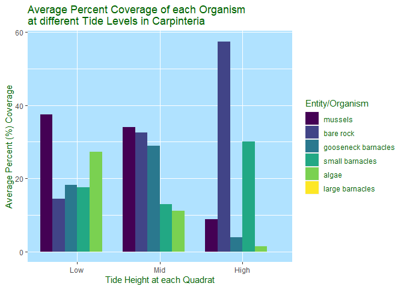

This plot shows the average percent coverage of each organism (and bare rock) on rocks at each tide height (Low, Mid, High) at Carpinteria, across all transects measured.

```r
# Generates plot
TidalPlot <- ggplot(data = tidal_summary,
                    mapping = aes(x = quadrat,
                                  y = avg_coverage,
                                  fill = fct_reorder(entity, avg_coverage, .desc = TRUE)))+ # re-orders entity by descending average coverage

  geom_bar(position = "dodge", stat = "identity")+ # specifies bar plot

  # specifies labels of plot elements
  labs(x = "Tide Height at each Quadrat",
       y = "Average Percent (%) Coverage",
       fill = "Entity/Organism",
       title = "Average Percent Coverage of each Organism
at different Tide Levels in Carpinteria")+

  # color-blind friendly colors
  scale_fill_viridis_d()+

  # specifies color of plot elements
  theme(panel.background = element_rect(fill = "lightskyblue1"),
        text = element_text(color = "darkgreen"))

TidalPlot
```